# Desafio

Predizendo probabilidade de adquirir seguro completo para automóveis

Author

Pedro Vinícius Alves Silva - 10727865

```r
#Bibliotecas requeridas
# require(ggplot2)
# require(GGally)
# require(dplyr)
# require(tibble)
# require(RColorBrewer)
# require(boot)
# require(ggsci)
# require(viridis)
# require(patchwork)
# require(hnp)
# require(Epi)
# require(car)
# require(R2jags)
# require(coda)
# require(formattable)
# require(randomForest)
# require(lattice)
```

# Amostragem da base e separação treino/teste

Essa seção faz a amostragem dos conjunto de dados e salva os arquivos resultantes em baseprincipal.csv, basetreino.csv e basetest.csv. Os códigos estão disponíveis no arquivo .Rmd.

# Análise Exploratória

## Apresentação dos Dados

Uma das modalidades de seguro de veículos é conhecida como cobertura completa e pode ser acionada para cubrir os custos de danos ao automóvel por qualquer tipo de acidente, colisão, furto, vandalismos, enchentes ou impacto causado por um objeto inanimado.

- **AGE** - variável inteira, idade em anos dos indivíduos
- **MEN** - variável binária, sexo dos indivíduos (1- Masculino, 0 - Feminino)
- **URBAN** - variável binária, área na qual o indivíduo dirige (1 - Área Urbana, 0 - Área Rural)
- **PRIVATE** - variável binária, forma de utilização do veículo (1 - Privada, 0 - Comercial)
- **SENIORITY** - variável inteira, tempo de carta de motorista
- **y** - variável binária, se o indivíduo adquiriu cobertura completa? (1 - possui cobertura completa, 0- não possui cobertura completa)

```r
data <- read.csv2('basetreino.csv', sep = ',')

data_test <- read.csv2('baseteste.csv', sep = ',')

data_test <- data_test %>%
  mutate_at(vars("URBAN", "MEN", "PRIVATE", "y"), as.factor)


head(data)
```

|  | y | MEN | URBAN | PRIVATE | AGE | SENIORITY |
| --- | --- | --- | --- | --- | --- | --- |
| 1 | 1 | 1 | 0 | 1 | 71 | 27 |
| 2 | 0 | 1 | 0 | 1 | 51 | 8 |
| 3 | 1 | 0 | 1 | 1 | 35 | 14 |
| 4 | 0 | 0 | 0 | 1 | 47 | 8 |
| 5 | 0 | 1 | 0 | 1 | 77 | 14 |
| 6 | 1 | 1 | 0 | 1 | 21 | 5 |

## Inconsistências

As colunas que podem apresentar algum tipo de inconsistência são Age e Seniority. Um indivíduo não poderia ter mais anos de carta de motorista do que de vida. Não temos nenhuma observação desse tipo no conjunto de treino.

```r
#inconsistência no conjunto de treino
inconsist1_treino <- data %>%
  filter(SENIORITY > AGE)
inconsist1_treino
```

| y | MEN | URBAN | PRIVATE | AGE | SENIORITY |
| --- | --- | --- | --- | --- | --- |

Encontramos uma inconsistência no conjunto de teste e procedemos a sua deleção.

```r
inconsist1_teste <- data_test %>%
  filter(SENIORITY > AGE)

inconsist1_teste
```

| y | MEN | URBAN | PRIVATE | AGE | SENIORITY |
| --- | --- | --- | --- | --- | --- |
| 1 | 1 | 0 | 1 | 33 | 34 |

```r
todel_index <- which(data_test$SENIORITY > data_test$AGE)

data_test <- data_test[-c(todel_index),]
```

Filtramos também indivíduos menores de idade e encontramos duas observações no conjunto de treino. Não temos informação sobre o país na qual a amostra foi retirada, então não podemos concluir sobre a possibilidade de se conseguir a habilitação antes dos 18 anos. Assim, procedemos para a deleção desses casos.

```r
inconsist2 <- data %>%
  filter(AGE < 18)
inconsist2
```

| y | MEN | URBAN | PRIVATE | AGE | SENIORITY |
| --- | --- | --- | --- | --- | --- |
| 0 | 1 | 0 | 1 | 15 | 3 |
| 1 | 1 | 1 | 1 | 17 | 2 |

```r
todel_index <- which(data$AGE < 18)
data <- data[-c(todel_index),]
```

Igualmente para o conjunto de teste, encontramos uma observação inconsistente e a deletamos:

```r
inconsist2 <- data_test %>%
  filter(AGE < 18)

inconsist2
```

| y | MEN | URBAN | PRIVATE | AGE | SENIORITY |
| --- | --- | --- | --- | --- | --- |
| 0 | 1 | 0 | 1 | 16 | 3 |

```r
todel_index <-which(data_test$AGE < 18)
data_test <- data_test[-c(todel_index),]
```

## Correlações

Inicialmente, fazemos uma análise de correlação para descobrir se as covariáveis possuem alguma forte relação linear entre si (multicolineariedade) ou com a variável resposta.

### Pearson

Aplicamos a correlação de Pearson para identificar correlação linear entre variáveis numéricas.

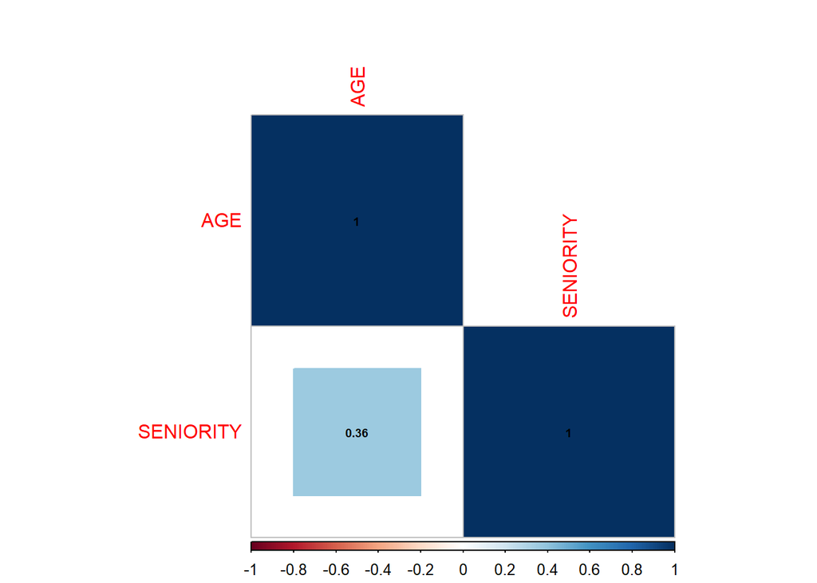

```r
numeric <- c("AGE", "SENIORITY")
df_pearson<- data[, numeric]



correl<- cor(df_pearson, method = 'pearson')

testRes = corrplot::cor.mtest(df_pearson, conf.level = 0.95, method = 'pearson')

corrplot::corrplot(correl, p.mat = testRes$p, addCoef.col ='black',method = 'square', order = 'FPC', type = 'lower', insig = 'blank', number.cex=0.6)
```

Vemos que Seniority e Age possuem uma correlação estatisticamente significante, ou seja, diferente de zero, porém de baixo módulo. Logo multicolinearidade não parece ser um problema.

### Spearman

Calculamos também o coeficiente de Spearman para identificar correlações monotônicas entre as variáveis. Valores faltantes indicam que a correlação é estatististicamente igual a zero ao nível de 5% de confiança.

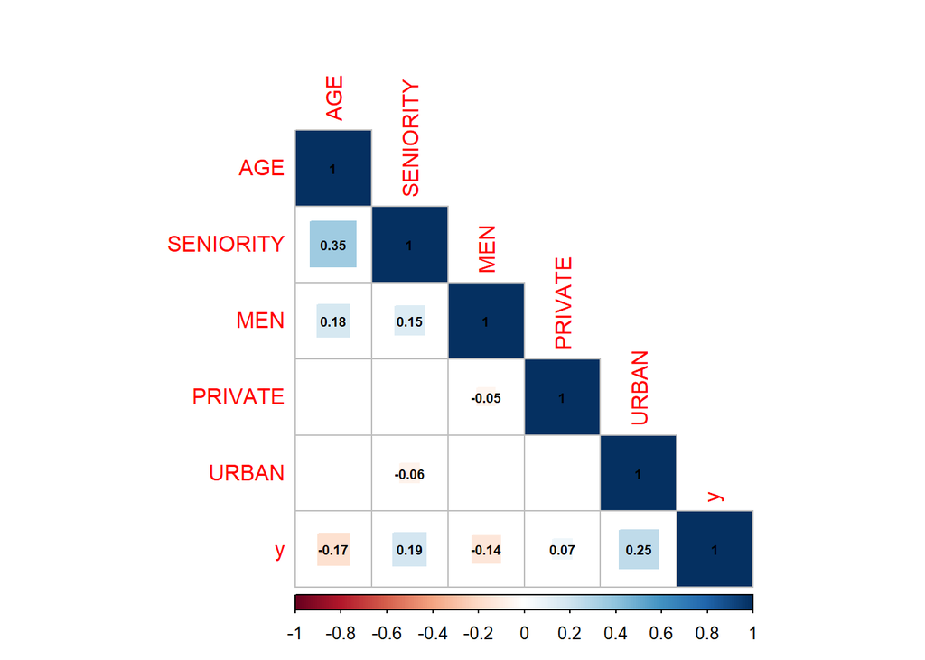

```r
numeric <- c("AGE", "SENIORITY", "y", "MEN", "URBAN", "PRIVATE")
df_spearman<- data[, numeric]



correl<- cor(df_spearman, method = 'spearman')

testRes = corrplot::cor.mtest(df_spearman, conf.level = 0.95, method = 'spearman')

corrplot::corrplot(correl, p.mat = testRes$p, addCoef.col ='black',method = 'square', order = 'FPC', type = 'lower', insig = 'blank', number.cex=0.6)
```

De forma geral, as correlações entre as covariáveis ou são fracas ou inexistentes. Em relação a variável resposta, temos que URBAN possui o maior valor em módulo, porém este também indica fraca correlação monotônica.

## Visão Geral dos Dados

A seguir verificamos a distribuição dos dados na base de treino. Inicialmente, notamos que os dados são relativamente desbalanceados em relação a variável resposta, já que temos mais de 50% de observações para y = 0. As covariáveis binárias também apresentam desbalanceio, sendo caso mais evidente da variável PRIVATE.

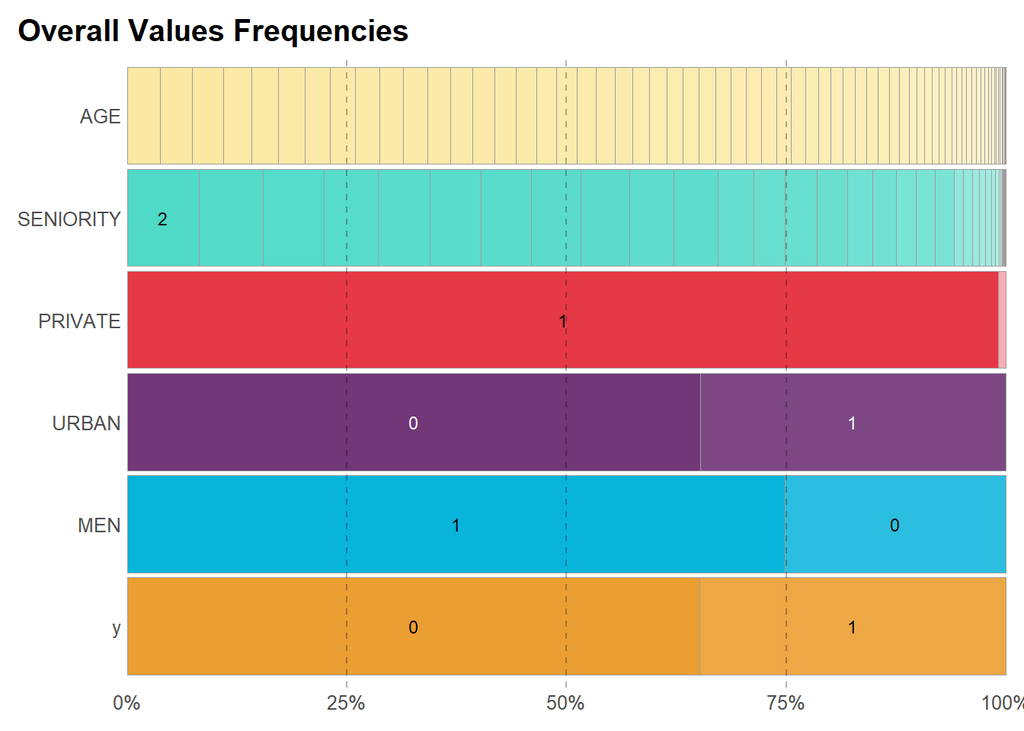

```r
library(lares)

freqs_df(data, plot = T)
```

Abaixo, temos um resumo quantitativo dos dados. A parte das variávies binárias, notamos que os indivíduos da base de treino tem em média 45 anos e 10 anos de carta de motorista.

```r
summary(data)
```

```
       y               MEN             URBAN           PRIVATE
 Min.   :0.0000   Min.   :0.0000   Min.   :0.0000   Min.   :0.0000
 1st Qu.:0.0000   1st Qu.:0.0000   1st Qu.:0.0000   1st Qu.:1.0000
 Median :0.0000   Median :1.0000   Median :0.0000   Median :1.0000
 Mean   :0.3484   Mean   :0.7489   Mean   :0.3476   Mean   :0.9914
 3rd Qu.:1.0000   3rd Qu.:1.0000   3rd Qu.:1.0000   3rd Qu.:1.0000
 Max.   :1.0000   Max.   :1.0000   Max.   :1.0000   Max.   :1.0000
      AGE          SENIORITY
 Min.   :18.00   Min.   : 2.00
 1st Qu.:36.00   1st Qu.: 5.00
 Median :45.00   Median : 9.00
 Mean   :46.06   Mean   :10.61
 3rd Qu.:55.00   3rd Qu.:15.00
 Max.   :88.00   Max.   :40.00
```

## Distribuição do Seguro por Covariáveis

Nessa seção, avaliamos quantitativamente a relação entre covariáveis e variável resposta.

### Seguro vs Sexo (MEN)

Como apresentado abaixo, a grande maioria dos dados são referentes a homens que não adquiriram o seguro completo. A porcentagem de mulheres é aproximadamente igual entre os grupos, indicando que não parece haver diferença entre a proporção de indivíduos do sexo feminino entre os dois grupos, contudo temos uma proporção maior de indivíduos do sexo masculino que não adquiriram seguro.

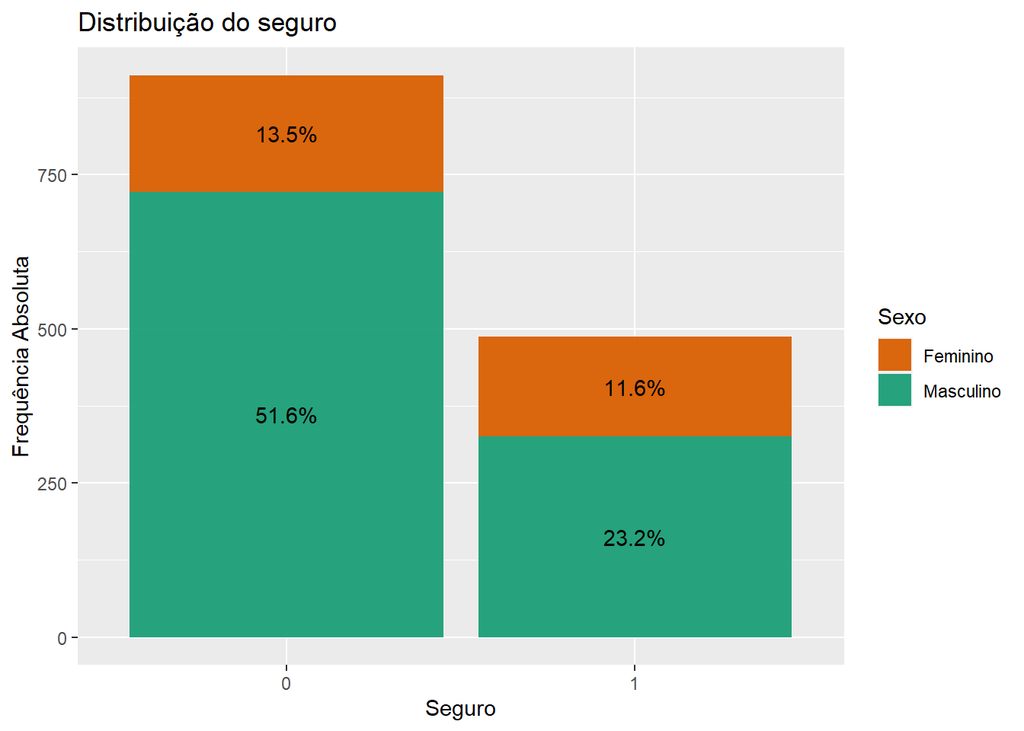

```r
hist_men <- ggplot(data %>% count(y, MEN) %>%
         mutate(pct=n/sum(n)),
       aes(as.factor(y), n, fill=as.factor(MEN))) +
  geom_bar(stat="identity") +
  geom_text(aes(label=paste0(sprintf("%1.1f", pct*100),"%")), position=position_stack(vjust=0.5)) +
scale_fill_manual(guide_legend(title="Sexo"), values = c("#D95F02", "#1B9E77"),labels = c("Feminino","Masculino")) +
  labs(x = 'Seguro', y = 'Frequência Absoluta', title = "Distribuição do seguro")


hist_men
```

Notamos também que a maioria dos dados são referentes a indivíduos que não possuem cobertura completa do seguro, tal desbalanceio pode dificultar a modelagem do problema.

```r
print(paste('Indíviduos sem cobertura completa',nrow(filter(data, y == '0'))))
```

```
[1] "Indíviduos sem cobertura completa 911"
```

```r
print(paste('Indíviduos com cobertura completa',nrow(filter(data, y == '1'))))
```

```
[1] "Indíviduos com cobertura completa 487"
```

### Seguro vs região onde dirige (URBAN)

A maior parte dos indivíduos dirigem em áreas rurais e não adquiriram o seguro completo. Também não notamos diferenças significativas entre a proporção de indivíduos com seguro completo que dirigem na área urbana, porém a maior parte dos indivíduos que dirigem na área rural não adquiriram seguro completo.

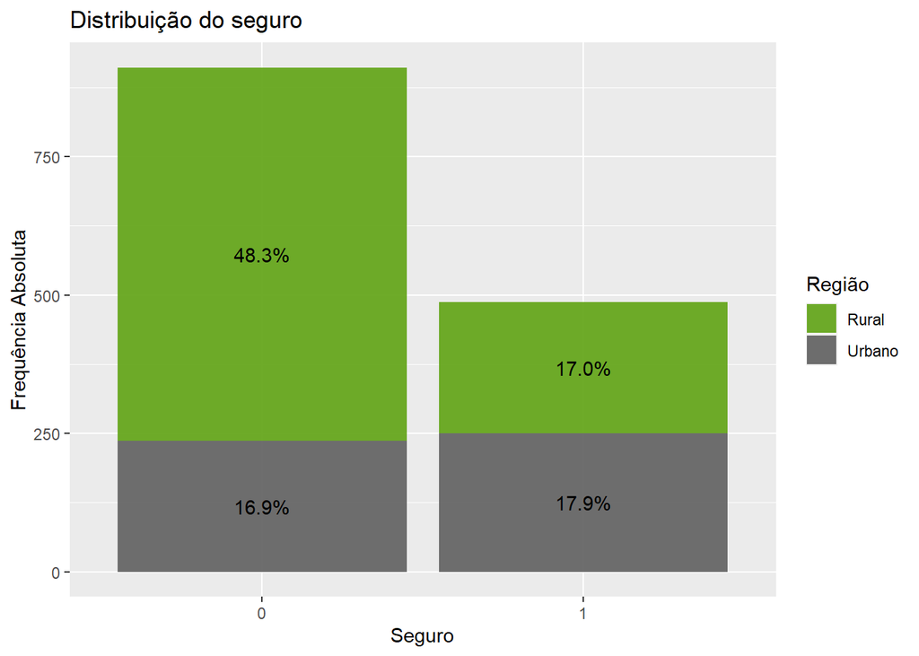

```r
hist_urban<- ggplot(data %>% count(y, URBAN) %>%
         mutate(pct=n/sum(n)),
       aes(as.factor(y), n, fill=as.factor(URBAN))) +
  geom_bar(stat="identity") +
  geom_text(aes(label=paste0(sprintf("%1.1f", pct*100),"%")), position=position_stack(vjust=0.5)) +
scale_fill_manual(guide_legend(title="Região"), values = c("#66A61E", "#666666"), labels = c("Rural","Urbano")) +
  labs(x = 'Seguro', y = 'Frequência Absoluta', title = "Distribuição do seguro")

hist_urban
```

### Seguro vs Uso de Veículo (PRIVATE)

Já para o tipo de uso do veículo, temos que 64.3% dos dados da amostra são de indivíduos que utilizam automóveis privativamente e não adquiriram o seguro completo. Nota-se também que apenas 0.9% dos dados referem-se a indivíduos que possuem veículos para uso comercial e todos eles não adquiriram seguro completo.

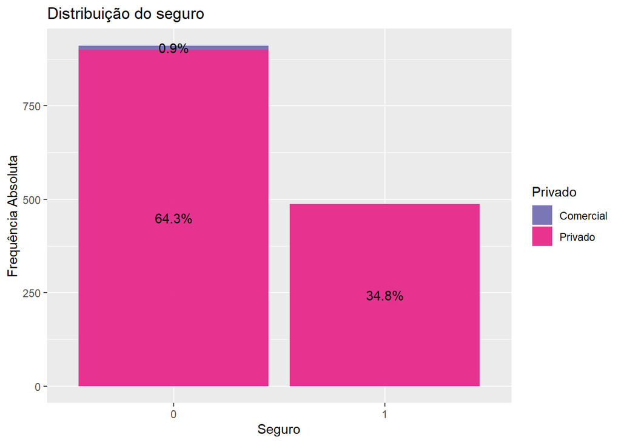

```r
hist_private<- ggplot(data %>% count(y, PRIVATE) %>%
         mutate(pct=n/sum(n)),
       aes(as.factor(y), n, fill=as.factor(PRIVATE))) +
  geom_bar(stat="identity") +
  geom_text(aes(label=paste0(sprintf("%1.1f", pct*100),"%")), position=position_stack(vjust=0.5)) +
scale_fill_manual(guide_legend(title="Privado"), values = c("#7570B3", "#E7298A"), labels = c("Comercial","Privado")) +
  labs(x = 'Seguro', y = 'Frequência Absoluta', title = "Distribuição do seguro")

hist_private
```

Se filtrarmos os indivíduos que usam veículos de forma comercial, também vemos que todos são do sexo masculino e não adquiriram o seguro completo.

```r
df <- data %>%
  filter(PRIVATE == 0)
df
```

| y | MEN | URBAN | PRIVATE | AGE | SENIORITY |
| --- | --- | --- | --- | --- | --- |
| 0 | 1 | 0 | 0 | 34 | 9 |
| 0 | 1 | 1 | 0 | 54 | 16 |
| 0 | 1 | 0 | 0 | 27 | 2 |
| 0 | 1 | 1 | 0 | 74 | 3 |
| 0 | 1 | 1 | 0 | 29 | 2 |
| 0 | 1 | 0 | 0 | 37 | 13 |
| 0 | 1 | 0 | 0 | 58 | 14 |
| 0 | 1 | 1 | 0 | 28 | 7 |
| 0 | 1 | 1 | 0 | 61 | 10 |
| 0 | 1 | 0 | 0 | 72 | 10 |

[output cut: 2 more lines]

### Idade e Tempo de Carteira

Avaliando a idade em relação as variáveis binárias, vemos que indivíduos que adquirem o seguro completo ou dirigem em área urbana tem em média uma menor idade. Por outro lado, indivíduos que fazem uso privado do automóvel ou são do sexo masculino são mais velhos que seus contrapontos.

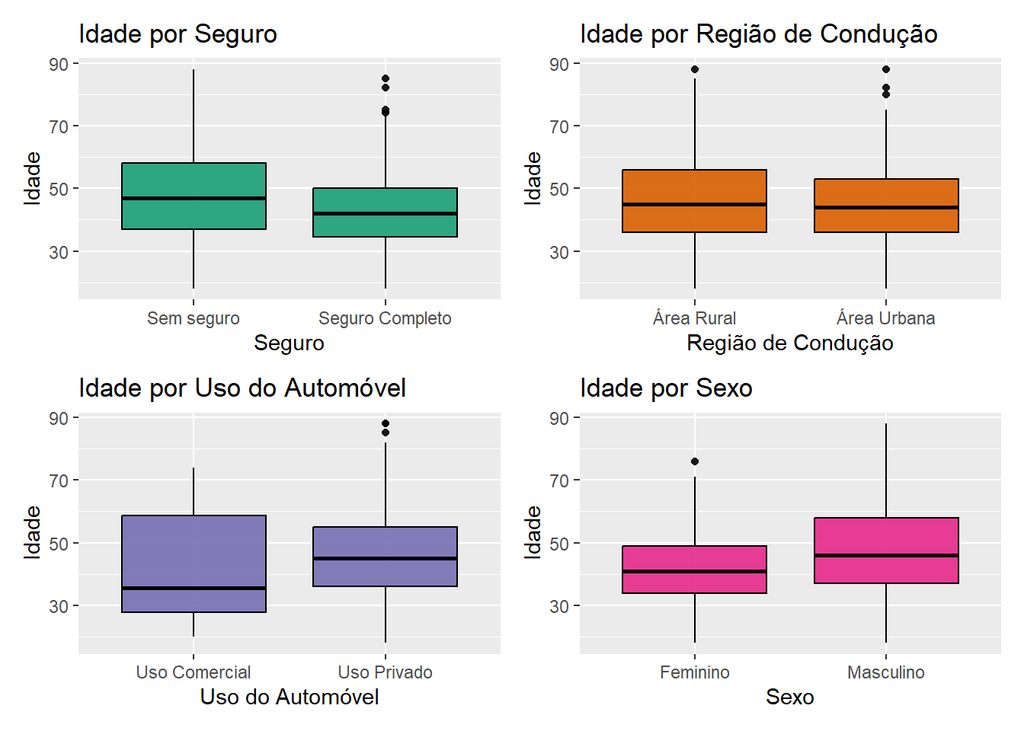

```r
p1 <- ggplot(data, aes(x=as.factor(y), y=AGE)) +
  geom_boxplot(notch=FALSE, fill = "#1B9E77", color = 'black') +
  scale_x_discrete(labels = c('Sem seguro', 'Seguro Completo'))+
  labs(title = 'Idade por Seguro',
       x = 'Seguro',
       y = 'Idade')

p2 <- ggplot(data, aes(x=as.factor(URBAN), y=AGE)) +
  geom_boxplot(notch=FALSE,fill = "#D95F02", color = 'black') +
    scale_x_discrete(labels = c('Área Rural', 'Área Urbana'))+
  labs(title = 'Idade por Região de Condução',
       x = 'Região de Condução',
       y = 'Idade')

p3 <- ggplot(data, aes(x=as.factor(PRIVATE), y=AGE)) +
  geom_boxplot(notch=FALSE,fill = "#7570B3", color = 'black') +
    scale_x_discrete(labels = c('Uso Comercial', 'Uso Privado'))+
  labs(title = 'Idade por Uso do Automóvel',
       x = 'Uso do Automóvel',
       y = 'Idade')

p4 <- ggplot(data, aes(x=as.factor(MEN), y=AGE, color = as.factor(y))) +
  geom_boxplot(notch=FALSE,fill = "#E7298A", color = 'black') +
    scale_x_discrete(labels = c('Feminino', 'Masculino'))+
  labs(title = 'Idade por Sexo',
       x = 'Sexo',
       y = 'Idade')

(p1|p2)/(p3|p4)
```

Para o tempo de carteira, notamos que indivíduos que não possuem seguro completo ou que fazem uso comercial do automóvel ou que sejam do sexo feminino, são em média mais novos do que seus opostos. Já indivíduos que dirigem pela área rural, parecem ter uma leve tendência a serem mais velhos do que indivíduos que dirigem na área urbana.

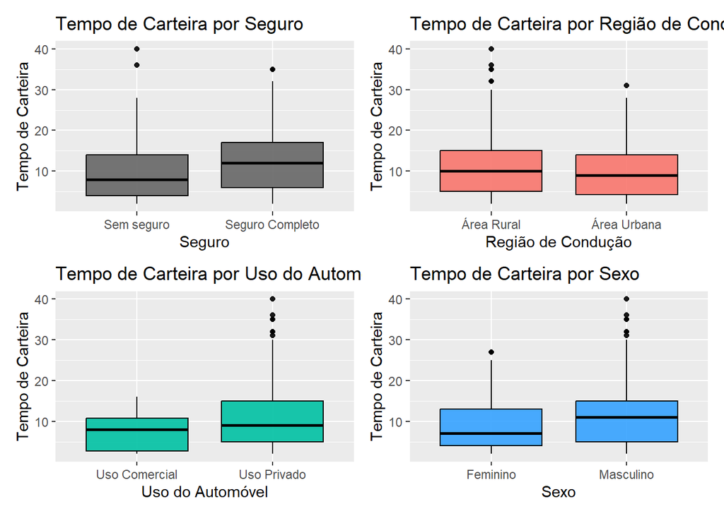

```r
p1 <- ggplot(data, aes(x=as.factor(y), y=SENIORITY)) +
  geom_boxplot(notch=FALSE, fill = "#666666", color = 'black') +
  scale_x_discrete(labels = c('Sem seguro', 'Seguro Completo'))+
  labs(title = 'Tempo de Carteira por Seguro',
       x = 'Seguro',
       y = 'Tempo de Carteira')

p2 <- ggplot(data, aes(x=as.factor(URBAN), y=SENIORITY)) +
  geom_boxplot(notch=FALSE,fill = "#F8766D", color = 'black') +
    scale_x_discrete(labels = c('Área Rural', 'Área Urbana'))+
  labs(title = 'Tempo de Carteira por Região de Condução',
       x = 'Região de Condução',
       y = 'Tempo de Carteira')

p3 <- ggplot(data, aes(x=as.factor(PRIVATE), y=SENIORITY)) +
  geom_boxplot(notch=FALSE,fill = "#00C1A3", color = 'black') +
    scale_x_discrete(labels = c('Uso Comercial', 'Uso Privado'))+
  labs(title = 'Tempo de Carteira por Uso do Automóvel',
       x = 'Uso do Automóvel',
       y = 'Tempo de Carteira')

p4 <- ggplot(data, aes(x=as.factor(MEN), y=SENIORITY)) +
  geom_boxplot(notch=FALSE,fill = "#35A2FF", color = 'black') +
    scale_x_discrete(labels = c('Feminino', 'Masculino'))+
  labs(title = 'Tempo de Carteira por Sexo',
       x = 'Sexo',
       y = 'Tempo de Carteira')

(p1|p2)/(p3|p4)
```

# Modelos Lineares Generalizados (Clássicos)

Nessa seção, temos o objetivo de ajustar o melhor modelo para predizer, dado as informações do indivíduo, se ele possui ou não cobertura completa do seguro.

```r
data_reg <- data %>%
  mutate_at(vars("URBAN", "MEN", "PRIVATE", "y"), as.factor)

data_test <- data_test %>%
  mutate_at(vars("URBAN", "MEN", "PRIVATE", "y"), as.factor)
```

## Regressão Logística (GLM com ligação logit)

Começamos ajustando um modelo de regressão logística clássico. Usamos todas as covariáveis possíveis e aplicamos testes de significância aos coeficientes.

```r
m0 <- glm(formula = y ~  URBAN + SENIORITY+ AGE + MEN + PRIVATE,
 family = binomial(link = "logit"), data = data_reg)

summary(m0)
```

```
Call:
glm(formula = y ~ URBAN + SENIORITY + AGE + MEN + PRIVATE, family = binomial(link = "logit"),
    data = data_reg)

Deviance Residuals:
    Min       1Q   Median       3Q      Max
-2.4302  -0.7949  -0.4924   1.0330   2.6766

Coefficients:
             Estimate Std. Error z value Pr(>|z|)
(Intercept) -14.34106  376.42929  -0.038    0.970
URBAN1        1.38994    0.13302  10.449  < 2e-16 ***
SENIORITY     0.13340    0.01159  11.508  < 2e-16 ***
AGE          -0.05711    0.00599  -9.534  < 2e-16 ***
MEN1         -0.71958    0.14393  -5.000 5.75e-07 ***
PRIVATE1     14.81859  376.42923   0.039    0.969
---
Signif. codes:  0 '***' 0.001 '**' 0.01 '*' 0.05 '.' 0.1 ' ' 1

(Dispersion parameter for binomial family taken to be 1)

    Null deviance: 1807.4  on 1397  degrees of freedom
Residual deviance: 1494.0  on 1392  degrees of freedom
AIC: 1506

Number of Fisher Scoring iterations: 14
```

O intercepto e o coeficiente de Private são não significativos, mas procederemos para a retirada apenas do segundo.

```r
m1_logit <- glm(formula = y ~  URBAN + SENIORITY+ AGE + MEN,
 family = binomial(link = "logit"), data = data_reg)
summary(m1_logit)
```

```
Call:
glm(formula = y ~ URBAN + SENIORITY + AGE + MEN, family = binomial(link = "logit"),
    data = data_reg)

Deviance Residuals:
    Min       1Q   Median       3Q      Max
-2.4332  -0.7940  -0.5024   1.0405   2.6796

Coefficients:
             Estimate Std. Error z value Pr(>|z|)
(Intercept)  0.448334   0.244105   1.837   0.0663 .
URBAN1       1.375878   0.132474  10.386  < 2e-16 ***
SENIORITY    0.134149   0.011578  11.586  < 2e-16 ***
AGE         -0.056425   0.005951  -9.481  < 2e-16 ***
MEN1        -0.745306   0.143671  -5.188 2.13e-07 ***
---
Signif. codes:  0 '***' 0.001 '**' 0.01 '*' 0.05 '.' 0.1 ' ' 1

(Dispersion parameter for binomial family taken to be 1)

    Null deviance: 1807.4  on 1397  degrees of freedom
Residual deviance: 1503.9  on 1393  degrees of freedom
AIC: 1513.9

Number of Fisher Scoring iterations: 4
```

Verificamos agora o ajuste do modelo utilizando os resíduos de quantil randomizados. De forma geral, se o modelo faz um bom ajuste dos dados, esperamos que apenas 5% dos pontos se encontrem fora do envelope simulado. Pelo envelope simulado gerado abaixo não notamos fortes desvios.

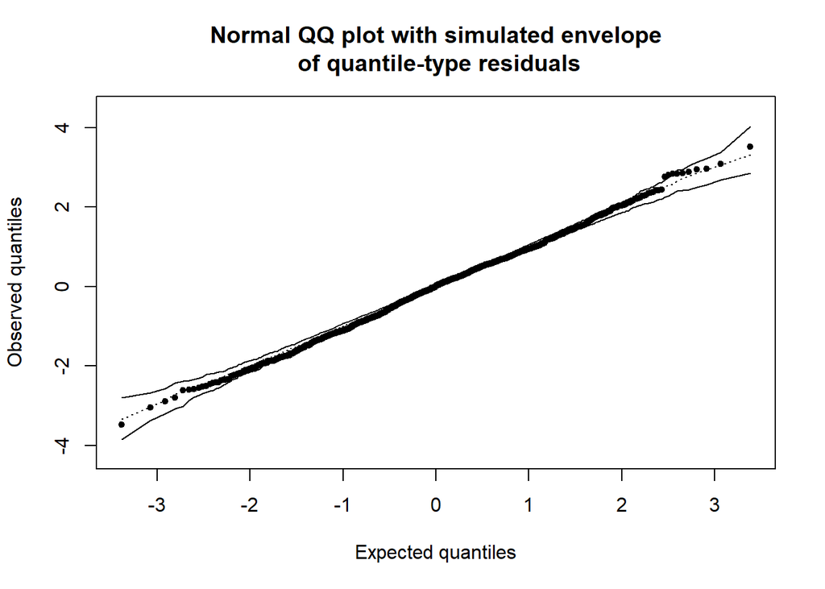

Ao analisar a curva ROC, obtemos um valor de 0.785 pra área sob a curva.

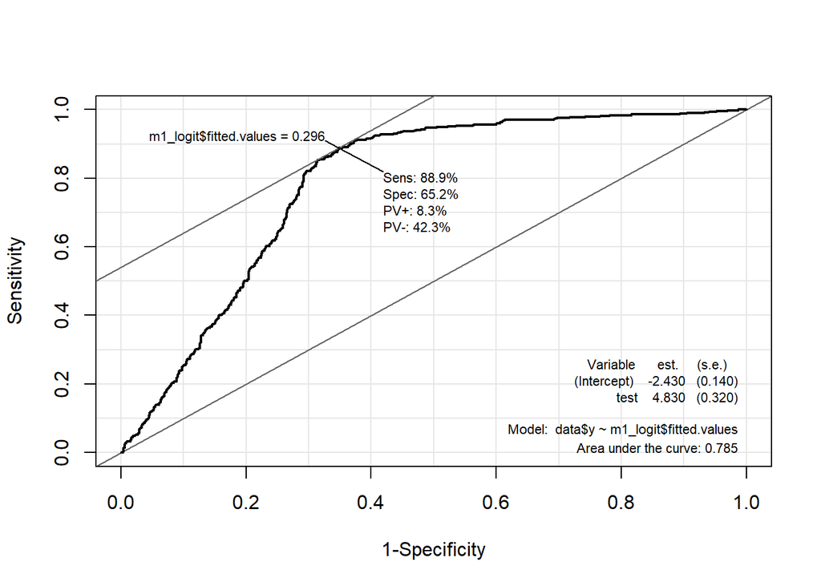

```r
library(Epi)
Epi::ROC(m1_logit$fitted.values, data$y, plot= "ROC")
```

## Regressão Logística (Probit, Cauchit, Cloglog, loglog)

### Probit

Ao utlizar a função de ligação probito, temos um modelo também sem indícios de mau ajuste e com área sob a curva também de 0.785.

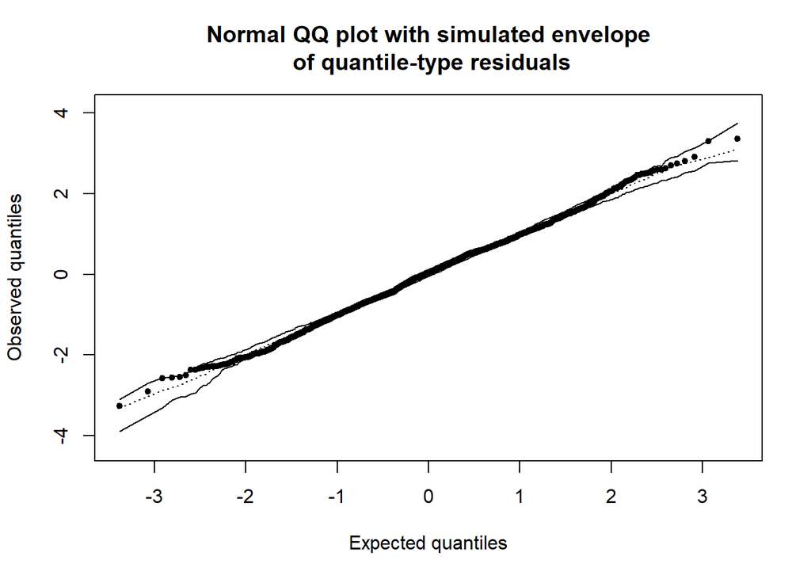

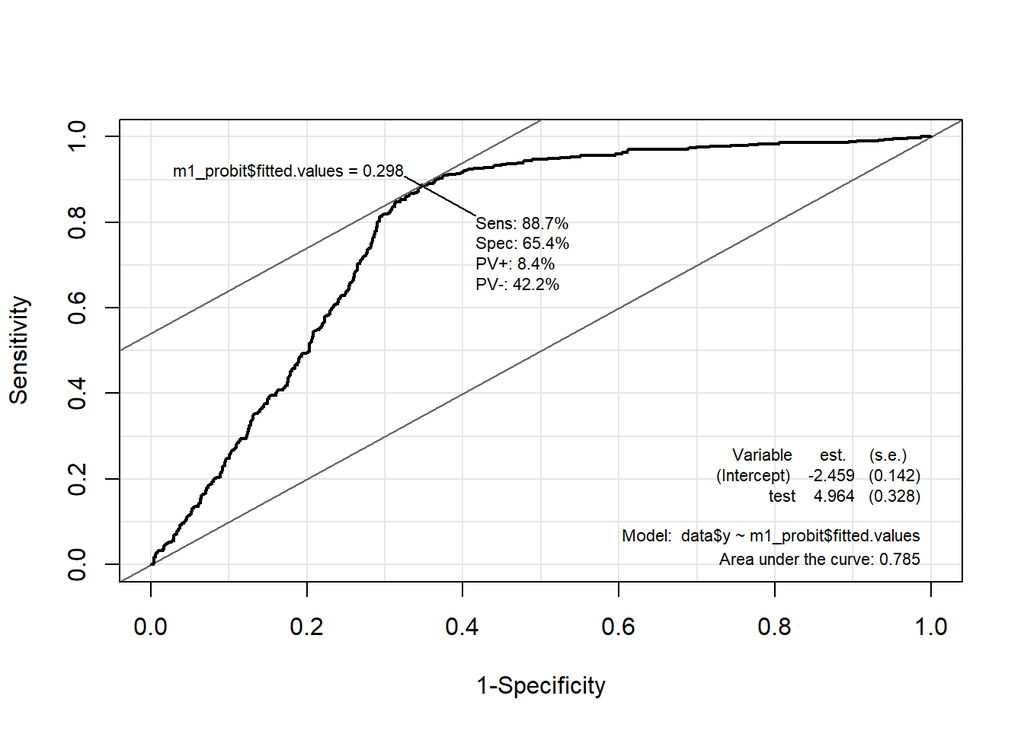

```r
summary(m1_probit)
```

```
Call:
glm(formula = y ~ URBAN + SENIORITY + AGE + MEN, family = binomial(link = "probit"),
    data = data_reg)

Deviance Residuals:
    Min       1Q   Median       3Q      Max
-2.4789  -0.7971  -0.4952   1.0597   2.8467

Coefficients:
             Estimate Std. Error z value Pr(>|z|)
(Intercept)  0.242315   0.145182   1.669   0.0951 .
URBAN1       0.822382   0.078025  10.540  < 2e-16 ***
SENIORITY    0.078098   0.006620  11.797  < 2e-16 ***
AGE         -0.033146   0.003405  -9.735  < 2e-16 ***
MEN1        -0.433073   0.085672  -5.055  4.3e-07 ***
---
Signif. codes:  0 '***' 0.001 '**' 0.01 '*' 0.05 '.' 0.1 ' ' 1

(Dispersion parameter for binomial family taken to be 1)

    Null deviance: 1807.4  on 1397  degrees of freedom
Residual deviance: 1502.4  on 1393  degrees of freedom
AIC: 1512.4

Number of Fisher Scoring iterations: 5
```

### Cauchit

Usando a função de ligação Cauchit:

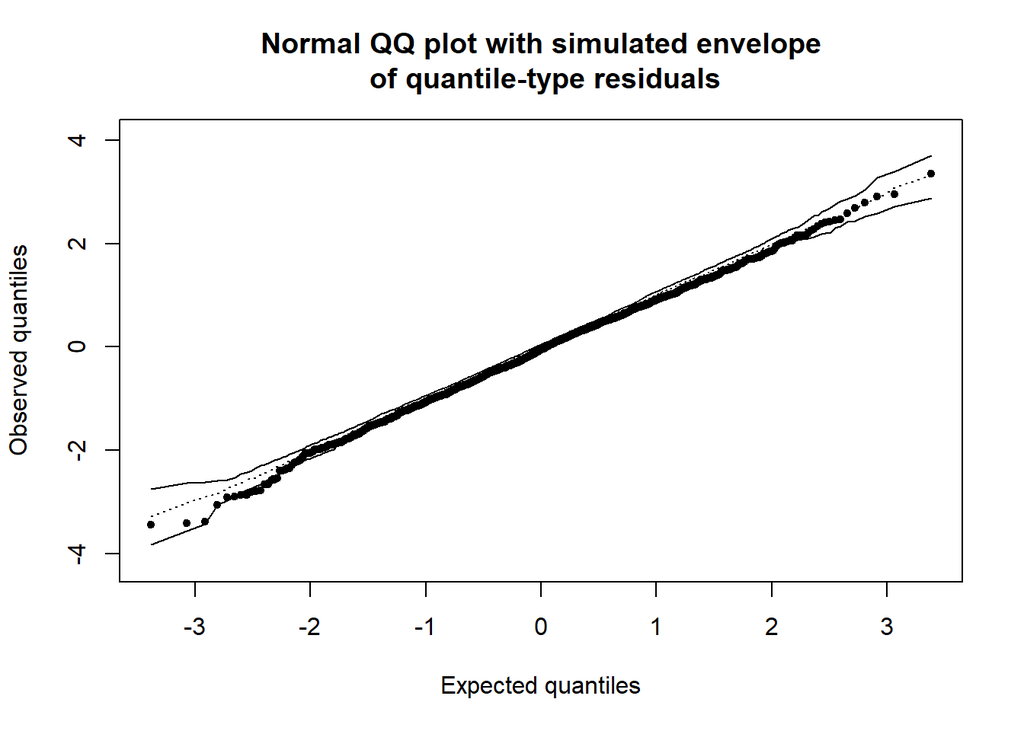

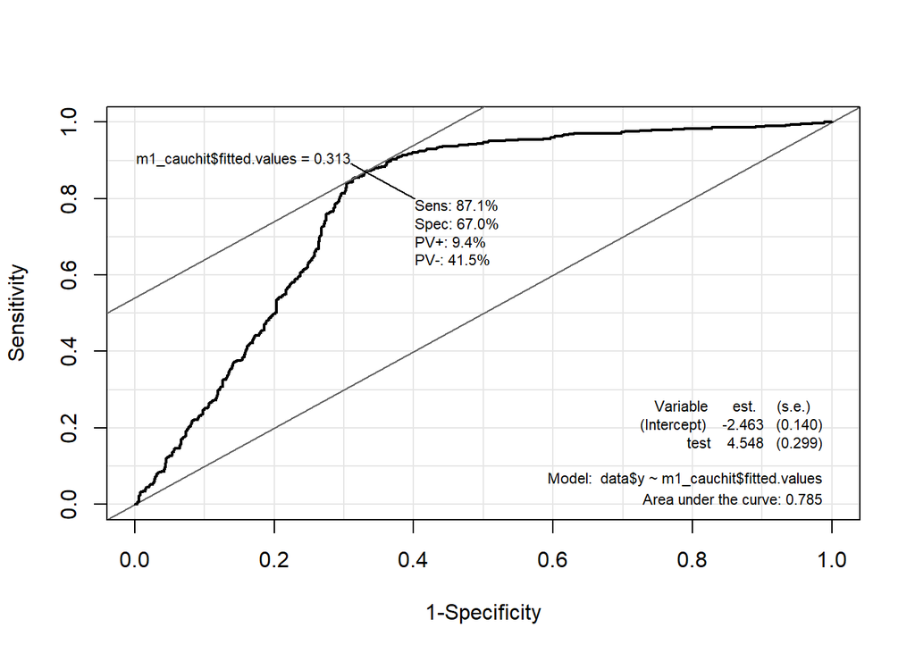

```r
summary(m1_cauchit)
```

```
Call:
glm(formula = y ~ URBAN + SENIORITY + AGE + MEN, family = binomial(link = "cauchit"),
    data = data_reg)

Deviance Residuals:
    Min       1Q   Median       3Q      Max
-2.1595  -0.8026  -0.5833   0.9427   2.1985

Coefficients:
             Estimate Std. Error z value Pr(>|z|)
(Intercept)  0.612386   0.244848   2.501   0.0124 *
URBAN1       1.356105   0.149978   9.042  < 2e-16 ***
SENIORITY    0.139137   0.014477   9.611  < 2e-16 ***
AGE         -0.056680   0.007021  -8.073 6.88e-16 ***
MEN1        -0.819398   0.148459  -5.519 3.40e-08 ***
---
Signif. codes:  0 '***' 0.001 '**' 0.01 '*' 0.05 '.' 0.1 ' ' 1

(Dispersion parameter for binomial family taken to be 1)

    Null deviance: 1807.4  on 1397  degrees of freedom
Residual deviance: 1524.5  on 1393  degrees of freedom
AIC: 1534.5

Number of Fisher Scoring iterations: 8
```

### Cloglog

Para a função de ligação Cloglog:

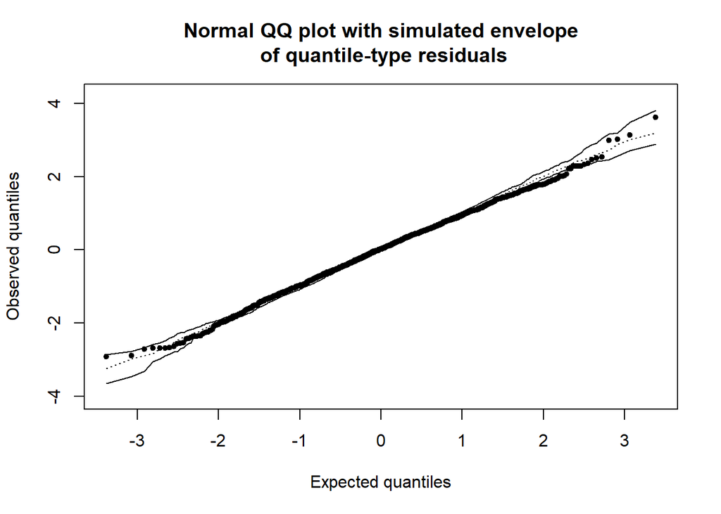

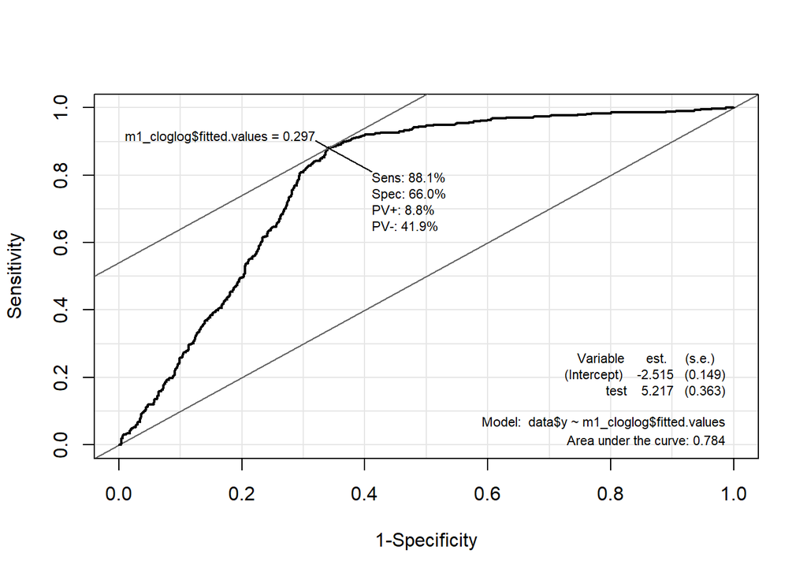

```r
summary(m1_cloglog)
```

```
Call:
glm(formula = y ~ URBAN + SENIORITY + AGE + MEN, family = binomial(link = "cloglog"),
    data = data_reg)

Deviance Residuals:
    Min       1Q   Median       3Q      Max
-2.7618  -0.8054  -0.5786   1.1169   2.3819

Coefficients:
             Estimate Std. Error z value Pr(>|z|)
(Intercept) -0.156985   0.185004  -0.849    0.396
URBAN1       0.921767   0.095309   9.671  < 2e-16 ***
SENIORITY    0.084626   0.007959  10.633  < 2e-16 ***
AGE         -0.038024   0.004453  -8.538  < 2e-16 ***
MEN1        -0.432057   0.103489  -4.175 2.98e-05 ***
---
Signif. codes:  0 '***' 0.001 '**' 0.01 '*' 0.05 '.' 0.1 ' ' 1

(Dispersion parameter for binomial family taken to be 1)

    Null deviance: 1807.4  on 1397  degrees of freedom
Residual deviance: 1538.1  on 1393  degrees of freedom
AIC: 1548.1

Number of Fisher Scoring iterations: 10
```

### Loglog

O modelo com função de ligação loglog:

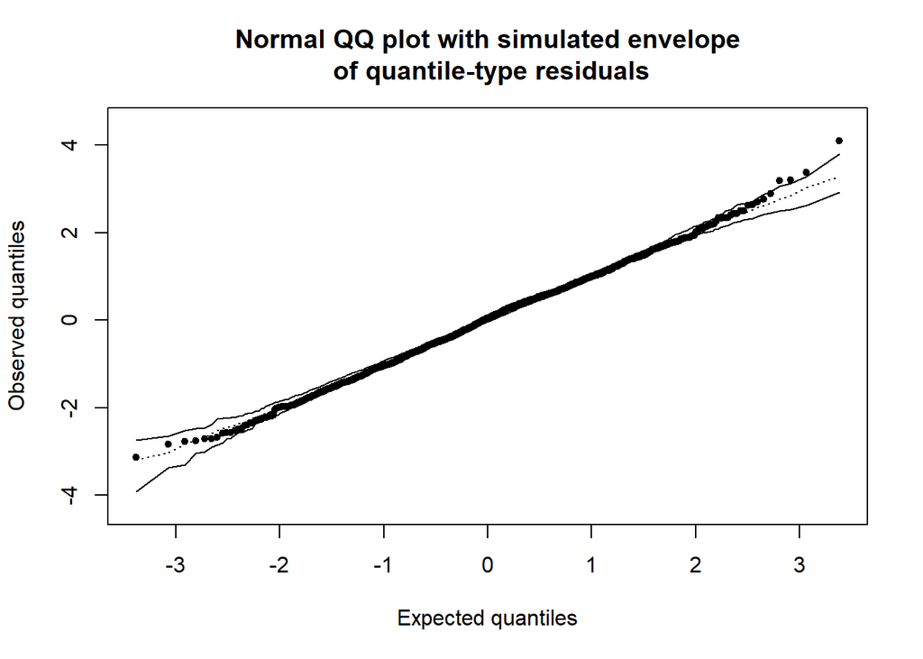

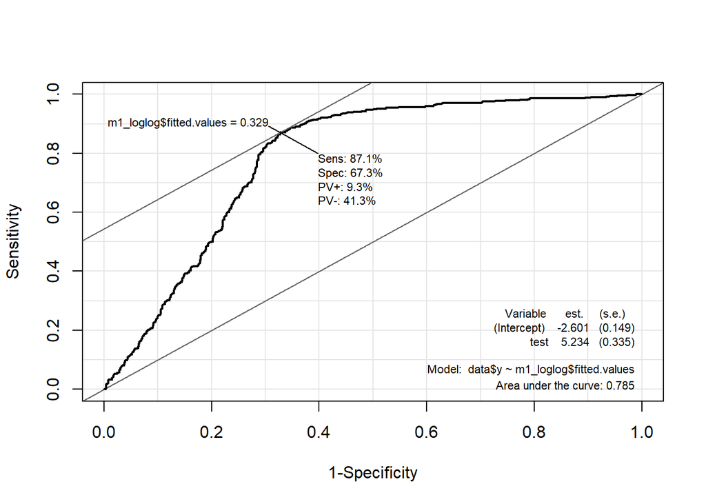

```r
summary(m1_loglog)
```

```
Call:
glm(formula = y ~ URBAN + SENIORITY + AGE + MEN, family = binomial(link = loglog()),
    data = data_reg)

Deviance Residuals:
    Min       1Q   Median       3Q      Max
-2.1272  -0.8219  -0.4540   1.0432   3.4517

Coefficients:
             Estimate Std. Error z value Pr(>|z|)
(Intercept)  0.632619   0.147459   4.290 1.79e-05 ***
URBAN1       0.889803   0.083497  10.657  < 2e-16 ***
SENIORITY    0.081249   0.006944  11.701  < 2e-16 ***
AGE         -0.033515   0.003320 -10.094  < 2e-16 ***
MEN1        -0.482435   0.090741  -5.317 1.06e-07 ***
---
Signif. codes:  0 '***' 0.001 '**' 0.01 '*' 0.05 '.' 0.1 ' ' 1

(Dispersion parameter for binomial family taken to be 1)

    Null deviance: 1807.4  on 1397  degrees of freedom
Residual deviance: 1484.1  on 1393  degrees of freedom
AIC: 1494.1

Number of Fisher Scoring iterations: 5
```

### AIC

Utilizamos o critério de Akaike para selecionar um modelo:

```r
# Dataframe para verificar o AIC
data.frame(Modelo=c("Modelo logito","Modelo probito","Modelo cauchito","Modelo cloglog","Modelo loglog"),
AIC = c(AIC(m1_logit),AIC(m1_probit),AIC(m1_cauchit),
AIC(m1_cloglog), AIC(m1_loglog)))
```

| Modelo | AIC |
| --- | --- |
| Modelo logito | 1513.942 |
| Modelo probito | 1512.401 |
| Modelo cauchito | 1534.467 |
| Modelo cloglog | 1548.091 |
| Modelo loglog | 1494.055 |

Comparando os modelos pelo critério de Akaike, temos que o modelo loglog tende o mais balanceado em relação a qualidade de ajuste e quantidade de parâmetros. A seguir, analisamos alavancagem e influência dos pontos utilizados no ajuste.

## Retirada de pontos influentes Loglog

O gráfico em azul apresenta a distância de Cook para identificar pontos influentes. O segundo gráfico mostra os resíduos studentizados e a tabela apresenta informações de alguns pontos apontados como outlier usando o teste de Bonferroni para outliers.

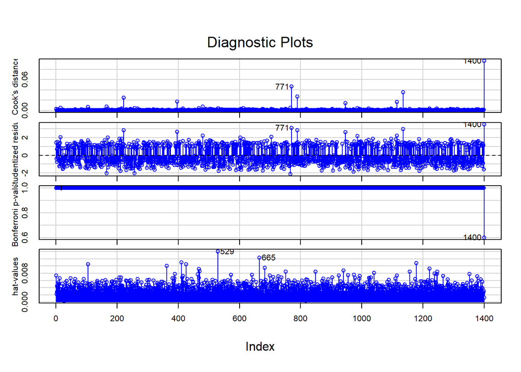

```r
#plot(m1_loglog)
influenceIndexPlot(m1_loglog,col='blue')
```

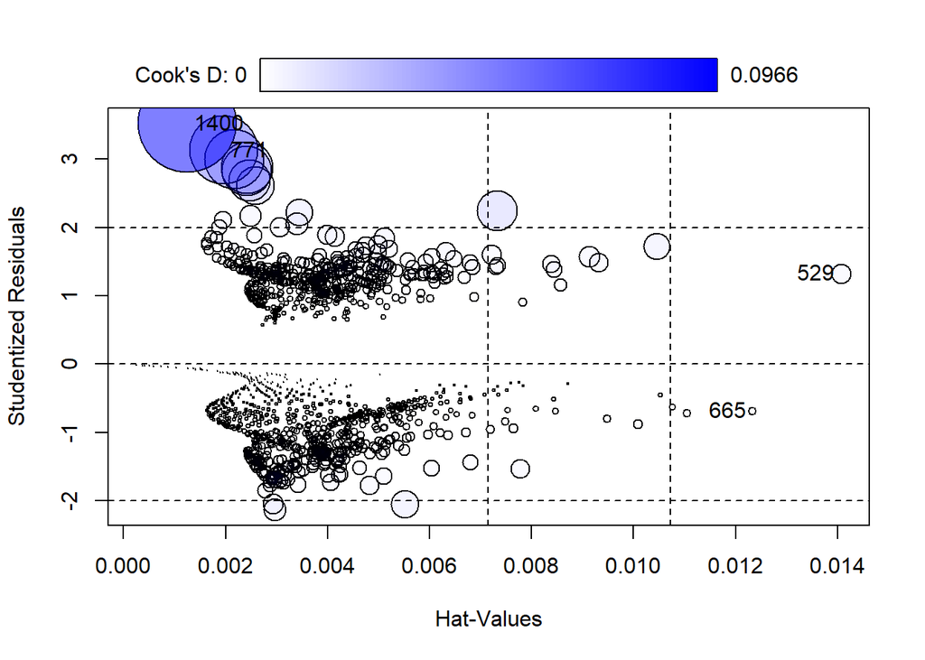

|  | StudRes | Hat | CookD |
| --- | --- | --- | --- |
| 529 | 1.3226722 | 0.014070114 | 0.0039799795 |
| 665 | -0.6879603 | 0.012335490 | 0.0006699527 |
| 771 | 3.1288347 | 0.001964524 | 0.0465263325 |
| 1400 | 3.5208389 | 0.001249995 | 0.0965990925 |

```r
influencePlot(m1_loglog)
```

Pelos valores de resíduos studentizados, temos que os pontos 771 e 1400 encontram-se foram do intervalor (-2,2).

Ajustamos um modelo considerando a retirada de cada ponto e um modelo considerando a remoção de ambos.

```r
ajuste1 <- glm(formula = y ~URBAN + SENIORITY+ AGE + MEN,
 family = binomial(link = loglog()), subset = -c(529) , data = data_reg)

ajuste2 <- glm(formula = y ~  URBAN + SENIORITY+ AGE + MEN,
 family = binomial(link = loglog()), subset = -c(665) , data = data_reg)

ajuste3 <- glm(formula = y ~  URBAN + SENIORITY+ AGE + MEN,
 family = binomial(link = loglog()), subset = -c(529,665) , data = data_reg)


compareCoefs(m1_loglog,ajuste1, ajuste2, ajuste3)
```

```
Calls:
1: glm(formula = y ~ URBAN + SENIORITY + AGE + MEN, family = binomial(link =
   loglog()), data = data_reg)
2: glm(formula = y ~ URBAN + SENIORITY + AGE + MEN, family = binomial(link =
   loglog()), data = data_reg, subset = -c(529))
3: glm(formula = y ~ URBAN + SENIORITY + AGE + MEN, family = binomial(link =
   loglog()), data = data_reg, subset = -c(665))
4: glm(formula = y ~ URBAN + SENIORITY + AGE + MEN, family = binomial(link =
   loglog()), data = data_reg, subset = -c(529, 665))

             Model 1  Model 2  Model 3  Model 4
(Intercept)    0.633    0.631    0.632    0.631
SE             0.147    0.147    0.147    0.147

URBAN1        0.8898   0.8881   0.8895   0.8878
SE            0.0835   0.0835   0.0835   0.0835

SENIORITY    0.08125  0.08117  0.08122  0.08114
SE           0.00694  0.00694  0.00695  0.00694

AGE         -0.03352 -0.03350 -0.03350 -0.03348
SE           0.00332  0.00332  0.00332  0.00332

MEN1         -0.4824  -0.4803  -0.4823  -0.4801
SE            0.0907   0.0908   0.0907   0.0908
```

Ao comparar os coeficientes entre os modelos não notamos diferenças significativas entre os coeficientes. Vejamos o impacto no AIC:

```r
data.frame(
Modelo= c("Completo", "Removendo 529", "Removendo 665",
"Removendo 529 e 665"),
AIC = c(AIC(m1_loglog),AIC(ajuste1), AIC(ajuste2), AIC(ajuste3)))
```

| Modelo | AIC |
| --- | --- |
| Completo | 1494.055 |
| Removendo 529 | 1493.381 |
| Removendo 665 | 1494.008 |
| Removendo 529 e 665 | 1493.334 |

Nota-se que o AIC diminui com a retirada de ambos os pontos. Sem uma base teórica que justifique a retirada desses pontos, não podemos simplesmente excluí-los da análise. Porém, vamos seguir utilizando o modelo reduzido para testar seu desempenho no conjunto de teste. Em seguida, ajustamos outros algoritmos para o conjunto de dados.

## Predição no Conjunto de Teste

Abaixo, calculamos as métricas de acurácia, precisão, recall e f1score para os modelos loglog completo e reduzido. Os resultados são apresentados no momento oportuno no relatório.

```r
#cálculo de predição no conjunto de teste
accuracy <- function(model, model_roc, test_df) {

  #use roc returned by Epi roc function

  thresh_index <- which.max(rowSums(model_roc$res[, c("sens", "spec")]))

  recall <- model_roc$res[thresh_index,][1,1]
  precision <- model_roc$res[thresh_index,][1,3]

  f1_score <- 2*(recall*precision)/(recall+precision)


  thresh <- as.double(rownames(model_roc$res[thresh_index,][1]))
  predict_test <- ifelse(predict(model, newdata = test_df, type = 'response') >= thresh, 1,0)

  acc <- mean(predict_test == test_df$y)

  return(c(acc,precision, recall,f1_score))

}
```

```r
#métricas para modelo reduzido
y_pred <- predict(ajuste3,newdata = data_test, type = 'response')
roc_logit <- Epi::ROC(y_pred, data_test$y, plot= T)

logitr_res_test <- accuracy(ajuste3, roc_logit, data_test )
logitr_acc_test <- logitr_res_test[1]
logitr_f1_test<-  logitr_res_test[4]
logitr_precision_test <- logitr_res_test[2]
logitr_recall_test <- logitr_res_test[3]
```

[output not shown]

```r
## métrica para modelo completo
y_pred <- predict(m1_loglog,newdata = data_test, type = 'response')
roc_loglog <- Epi::ROC(y_pred, data_test$y, plot= F)

loglog_res_test <- accuracy(m1_loglog, roc_loglog, data_test )
loglog_acc_test <- loglog_res_test[1]
loglog_f1_test<-  loglog_res_test[4]
loglog_precision_test <- loglog_res_test[2]
loglog_recall_test <- loglog_res_test[3]
```

# Random Forest

O algoritmo de RandomForest trata-se de uma combinação de árvores de classificação. Os resultados gerados em diferentes árvores são posteriomente agregados em um único, de forma a reduzir a chance de superajuste (overfitting) e aumentar a acurácia.

Inicialmente, usamos a função tuneRF para encontrar o valor de mtry (número de variáveis aleatoriamente amostradas para ajustar as árvores).

```
mtry = 2  OOB error = 31.97%
Searching left ...
mtry = 4    OOB error = 33.55%
-0.049217 0.05
Searching right ...
mtry = 1    OOB error = 34.62%
-0.08277405 0.05
```

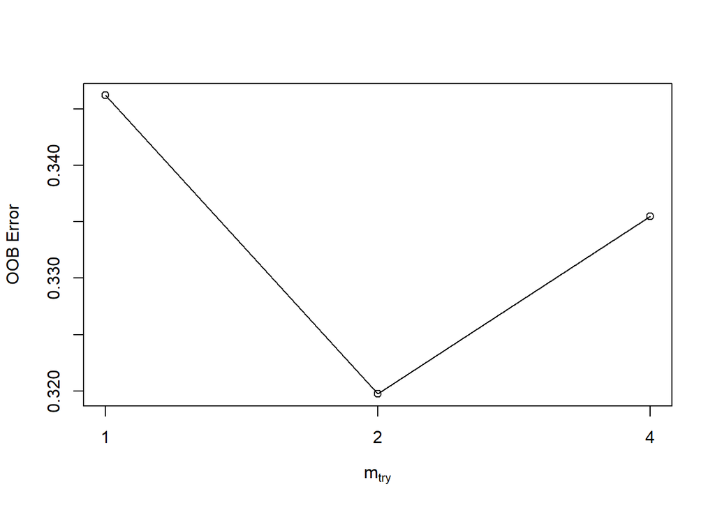

Usando mtry = 2, usamos randomForest para ajustar o modelo.

```r
rf <- randomForest(y~., data=data_reg, proximity=TRUE, mtry = 2)
print(rf)
```

```
Call:
 randomForest(formula = y ~ ., data = data_reg, proximity = TRUE,      mtry = 2)
               Type of random forest: classification
                     Number of trees: 500
No. of variables tried at each split: 2

        OOB estimate of  error rate: 31.12%
Confusion matrix:
    0   1 class.error
0 684 227   0.2491767
1 208 279   0.4271047
```

```r
#plot(rf)
```

[output not shown]

Também olhamos para a importância das covariáveis na classificação usando o Decréscimo Médio no Índice de Gini e vemos que a idade (AGE) e tempo de carteira (SENIORITY) parecem serem os fatores mais determinantes para um indivíduo adquirir o seguro completo.

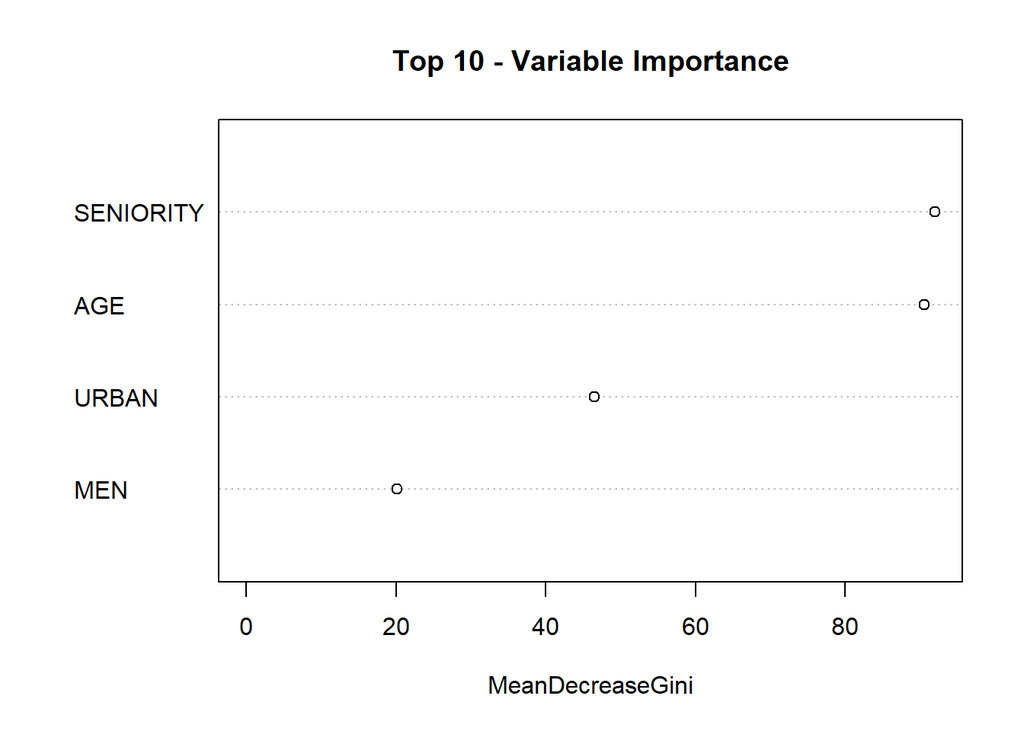

```r
#hist(treesize(rf),
#     main = "No. of Nodes for the Trees",
#     col = "green")
varImpPlot(rf,
           sort = T,
           n.var = 4,
           main = "Top 10 - Variable Importance")
```

```r
importance(rf)
```

```
          MeanDecreaseGini
MEN              20.096597
URBAN            46.437964
PRIVATE           2.872492
AGE              90.587071
SENIORITY        91.939768
```

# Soluções Bayesianas

## Modelo Cauchit

$$Y_i |\beta,\delta \sim Bernoulli(F(x_i\beta)) \\$$

$$\beta \sim N(0,100) \\$$

$$\lambda = \exp(\delta) \\$$

Em que:

$$F(x_i| \beta) = 1-(\frac{1}{\pi}arctan(z)+0.5)^{\lambda}$$

```r
modelString="
model{
  for (i in 1:N) {
    y[i] ~ dbern(p[i])
    m[i] <- beta0+beta_urban*URBAN[i] + beta_sen*SEN[i] + beta_age*AGE[i] + beta_men*MEN[i]
    pstar[i] <- 1/3.141592* arctan(-m[i]) + 1/2
    p[i] <- 1-pow(pstar[i], lambda)

  }
  beta0 ~ dnorm(0,100)
  delta ~ dunif(-2,2)
  lambda <- exp(delta)
  beta_urban ~ dnorm(0,100)
  beta_sen ~ dnorm(0,100)
  beta_age ~ dnorm(0,100)
  beta_men ~ dnorm(0,100)

  }

"
writeLines(modelString, con='models/m1_cauchit.bug')
```

```r
data_scaled = data
data_scaled$AGE <- as.numeric(scale(data$AGE))
data_scaled$SENIORITY <- as.numeric(scale(data$SENIORITY))

N = nrow(data_scaled)
jagsData <- list(N = N, y = data_scaled$y,
    URBAN = data_scaled$URBAN, SEN = data_scaled$SENIORITY    ,AGE = data_scaled$AGE, MEN = data_scaled$MEN)
```

Analisamos os diagnósticos de convergência e não encontramos nenhum indicativo de não convergência. Apresentamos também os gráfico das posteriores dos parâmetros:

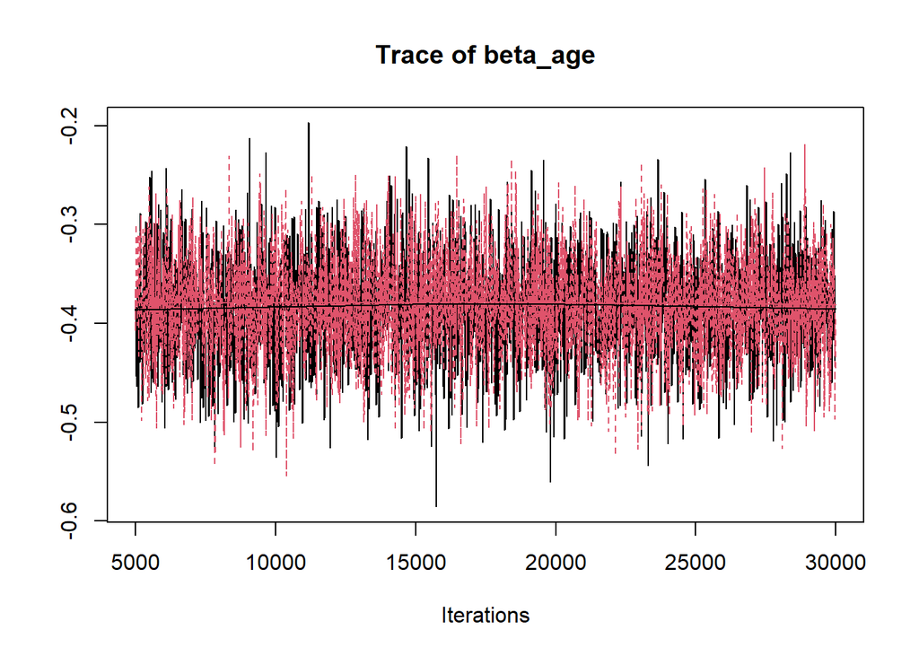

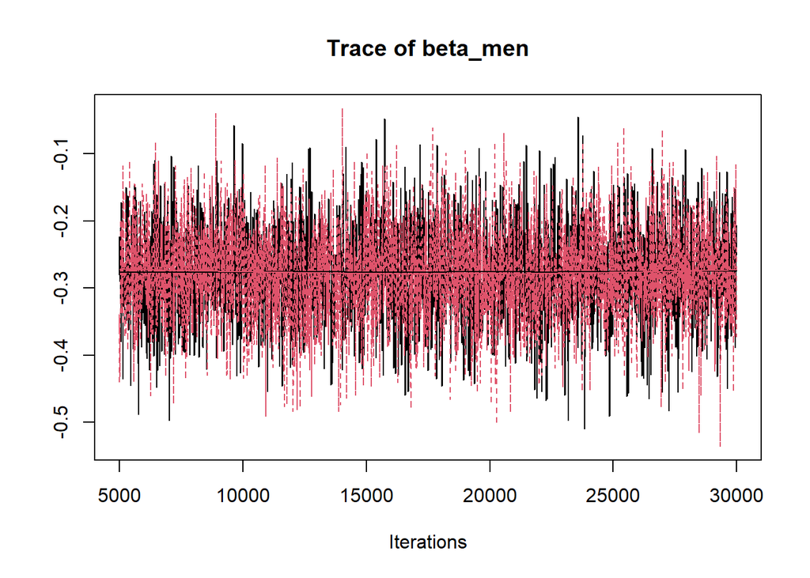

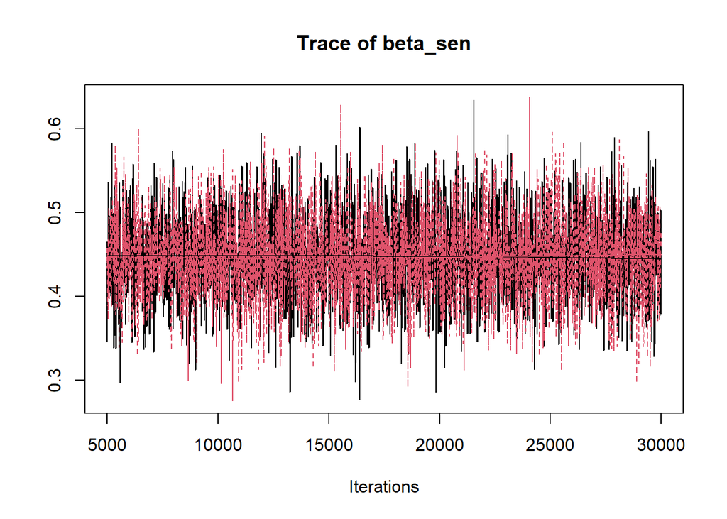

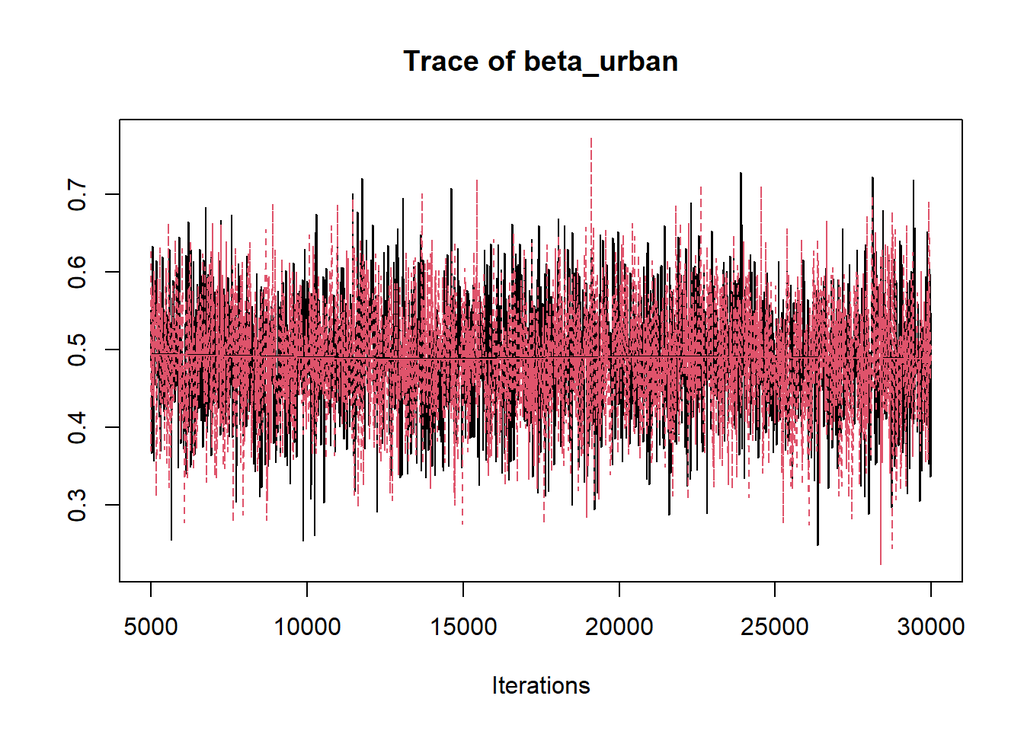

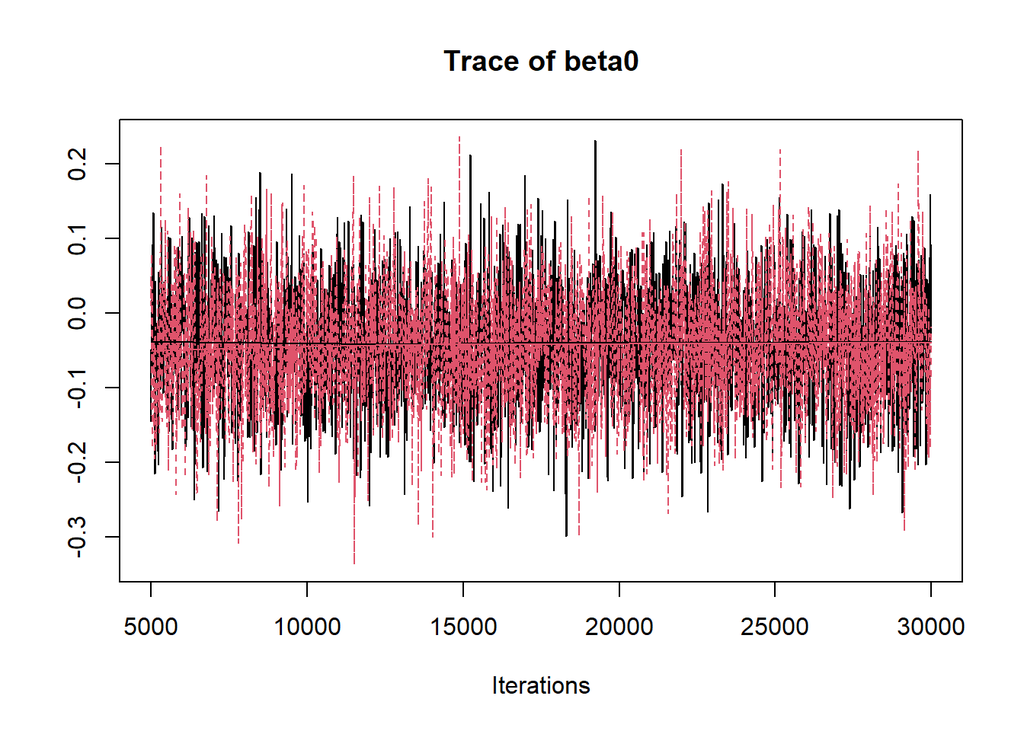

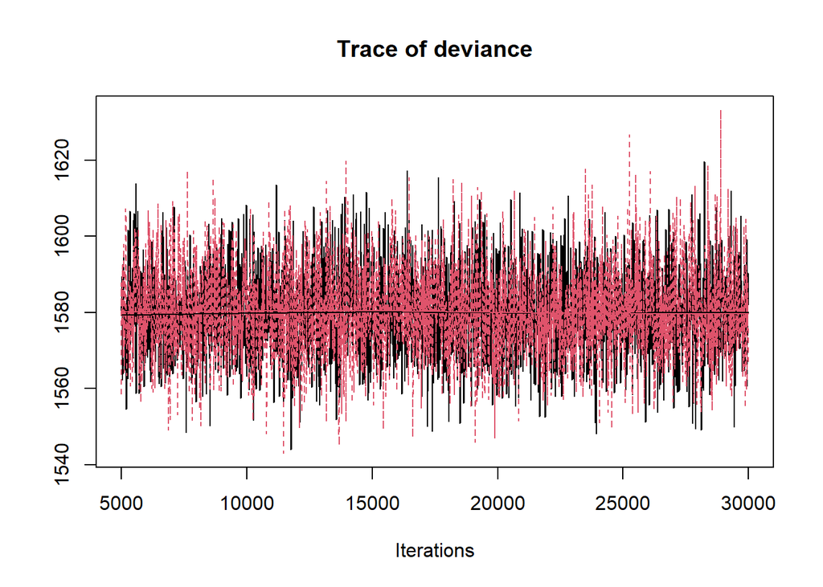

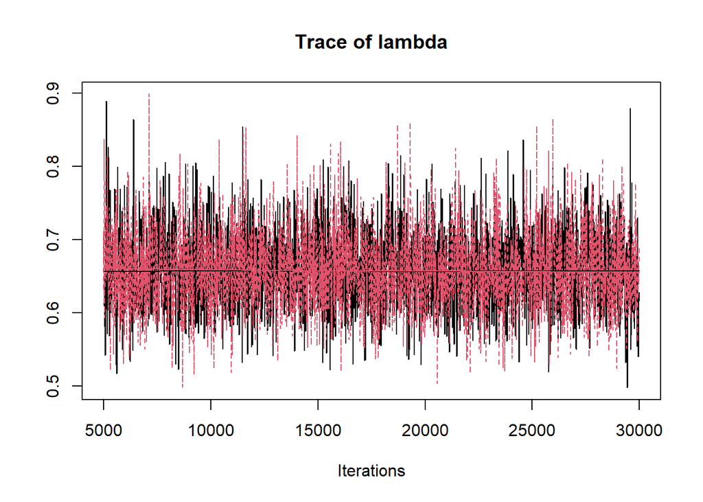

```r
mcmc.samples <- as.mcmc(m1_blogit)
traceplot(mcmc.samples)
```

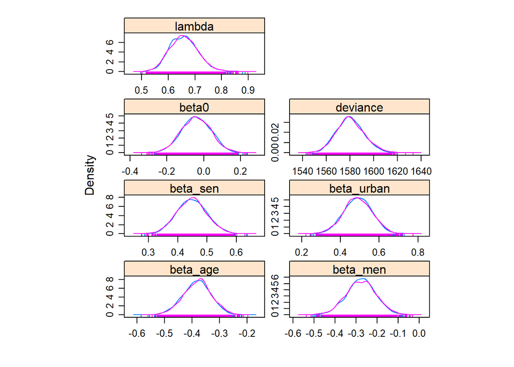

```r
densityplot(mcmc.samples)
```

## Predição nos conjuntos de treino e teste

```r
predict_bcauchit <- function(jagsfit.mcmc, data) {
# data deve ser do tipo dataframe

#vetor da média dos coeficientes beta_age/beta_men/beta_sen/beta_urban
coef <- as.matrix(summary(jagsfit.mcmc)$statistics[, 'Mean'][1:5])
lambda <- as.matrix(summary(jagsfit.mcmc)$statistics[, 'Mean'])[7]


data_matrix <- data.matrix(data)[,c(-1,-4)][, c(3,1,4,2)]
data_matrix <- cbind(data_matrix, intercept = 1)
n <- dim(data_matrix)[1]


#coef * data
res <- t(coef) %*% t(data_matrix)
res_vec <- as.vector(res)


pstar <- 1/pi* atan(-res_vec) + 0.5
p <- 1- pstar^lambda

predictions <- rbinom(n, 1, p)

return(predictions)
}



accuracy_bayes <- function(model_roc, test_df, predict) {

  #use roc returned by Epi roc function

  thresh_index <- which.max(rowSums(model_roc$res[, c("sens", "spec")]))

  recall <- model_roc$res[thresh_index,][1,1]
  precision <- model_roc$res[thresh_index,][1,3]

  f1_score <- 2*(recall*precision)/(recall+precision)


  thresh <- as.double(rownames(model_roc$res[thresh_index,][1]))


  acc <- mean(predict == test_df$y)

  return(c(acc,precision, recall,f1_score))

}

pred_test <- predict_bcauchit(mcmc.samples,data_test)


roc_bayes <- Epi::ROC(pred_test, data_test$y, plot= F)


thresh_index <- which.max(rowSums(roc_bayes$res[, c("sens", "spec")]))

recall <- roc_bayes$res[thresh_index,][1,1]
precision <- roc_bayes$res[thresh_index,][1,3]

metrics_bayes <- accuracy_bayes(roc_bayes, data_test, pred_test )
acc_bayes <- metrics_bayes[1]
prec_bayes <- metrics_bayes[2]
recall_bayes<-metrics_bayes[3]
f1_bayes <- metrics_bayes[4]
```

# Predição no conjunto de teste

A seguir,testamos o poder de predição dos modelos loglog com o conjunto de dados completo e reduzido e os outros modelos implementados. Aplicamos novamente a curva ROC e calculos as seguintes métricas:

- **Acurácia**: para mensurar o desempenho médio do modelo na classificação de indivíduos propensos a adquirir seguro completo
- **Precisão**: mensura a proporção de classificações corretas na classe positiva entre todas as classificações positivas
- **Recall**: mensura a proporção de casos corretamente classificados como positivo entre todos os casos que são de fato positivos.
- **F1-Score:** média harmônica entre precisão e recall

Para o caso do seguro, podemos incorrer em erros de falsos positivos(classificar como 1 quando o correto seria 0) ou falsos negativos (classificar como 0 quando o correto seria 1). O primeiro caso ocasionaria a abordagem de clientes com baixa propensão a adquirir o seguro completo, já o segundo resultaria em não abordar clientes com alto potencial de comprar o seguro. Como o segundo tipo de erro é financeiramente mais danoso a uma companhia, usaremos o recall como critério de escolha preferencial para o melhor modelo, uma vez que um valor alto recall significa um baixo número de falsos negativos.

```r
# Load the required libraries

# Create a data frame with the data
data <- data.frame(
  Modelo = c("Modelo loglog", "Modelo loglog Reduzido", "Random Forest", "Cauchit Potência Inversa"),
  'Acurácia' = round(c(loglog_acc_test, logitr_acc_test, acc_rf, acc_bayes),3),
  'Precisão' = round(c(loglog_precision_test, logitr_precision_test, precision_forest, prec_bayes),3),
  'Recall' = round(c(loglog_recall_test, logitr_recall_test, recall_forest, recall_bayes),3),

 'F1Score' = round(c(loglog_f1_test, logitr_f1_test, f1_forest, f1_bayes),3)
)






# Create a formattable
formattable(data,
                  align = c("l", "r", "r") # Set alignment for each column
)
```

| Modelo | Acurácia | Precisão | Recall | F1Score |
| --- | --- | --- | --- | --- |
| Modelo loglog | 0.722 | 0.082 | 0.884 | 0.151 |
| Modelo loglog Reduzido | 0.722 | 0.082 | 0.884 | 0.151 |
| Random Forest | 0.712 | 0.801 | 0.757 | 0.778 |
| Cauchit Potência Inversa | 0.669 | 0.330 | 0.020 | 0.038 |

```r
# Print the formattable
```

# Bibliografia

1. BÁZAN, J.L.Power and reversal power links for binary  
   regressions: An application for motor insurance  
   policyholders. **Wiley Online Library,** wileyonlinelibrary.com, 23/11/2016
2. **Bayesian Logistic Regression Tutorial**, https://www.flutterbys.com.au/stats/tut/tut10.5b.html, **Acessado por último em** :11/05/2023
3. SHUNG, Koo Ping, **Accuracy, Precision, Recall or F1?**, https://towardsdatascience.com/accuracy-precision-recall-or-f1-331fb37c5cb9. **Acessado por último em:** 11/05/2023
4. BROWLEE, Jason, **Tune Machine Learning Algorithms in R (random forest case study)**, https://machinelearningmastery.com/tune-machine-learning-algorithms-in-r/, **Acesso por último em:** 11/05/2023.

```r
knitr::knit_exit()
```